# Homework 1

```r
Elite =rep ("No",nrow(college ))
Elite [college$Top10perc >50]=" Yes"
Elite =as.factor (Elite)
college =data.frame(college ,Elite)
summary(college$Elite)
```

```
##  Yes   No
##   78  699
```

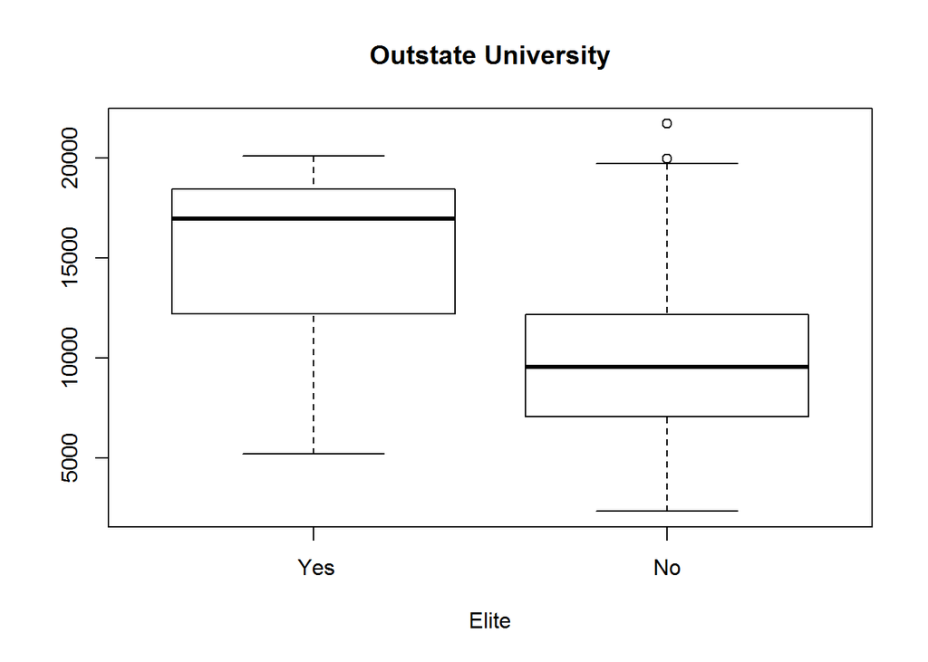

```r
plot(college$Elite,college$Outstate,xlab="Elite",main="Outstate University")
```

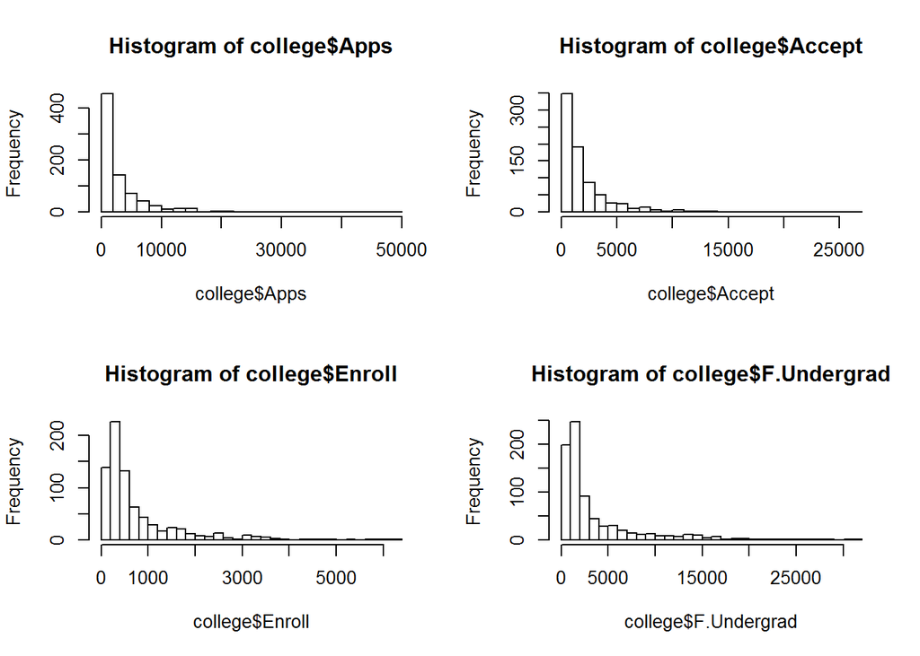

```r
par(mfrow=c(2,2))
hist(college$Apps,breaks=30)
hist(college$Accept,breaks = 30)
hist(college$Enroll,breaks = 30)
hist(college$F.Undergrad,breaks = 30)
```

```r
college$acc.rate <- college$Accept/college$Apps
CreateTableOne(data=college,vars = c("Elite","Apps","Accept","acc.rate"),factorVars = "Private",strata = "Private")
```

```
##                       Stratified by Private
##                        No                Yes               p      test
##   n                        212               565
##   Elite = No (%)           199 (93.9)        500 (88.5)     0.037
##   Apps (mean (sd))     5729.92 (5370.68) 1977.93 (2443.34) <0.001
##   Accept (mean (sd))   3919.29 (3477.27) 1305.70 (1369.55) <0.001
##   acc.rate (mean (sd))    0.73 (0.15)       0.75 (0.15)     0.018
```

## Chapter 3

### 9. (a)

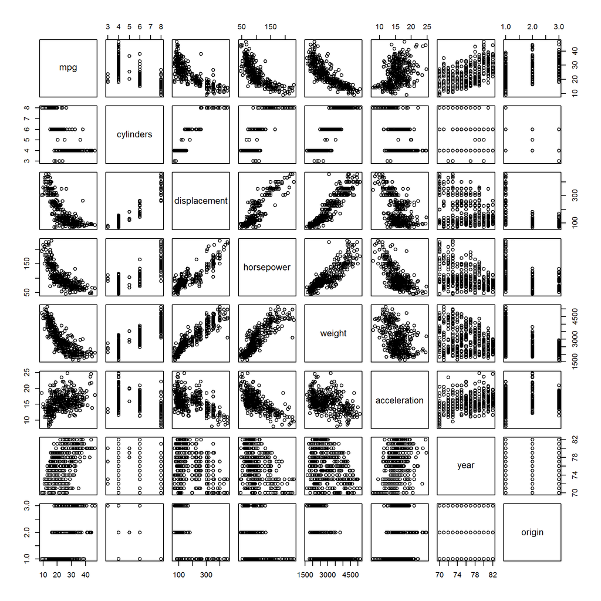

```r
auto <-read.csv("Auto.csv")%>%
          mutate(horsepower=as.numeric(as.character(horsepower)))
pairs(auto[,-9])
```

### (b)

```r
cor(na.omit(auto[,-9]))
```

```
##                     mpg  cylinders displacement horsepower     weight
## mpg           1.0000000 -0.7776175   -0.8051269 -0.7784268 -0.8322442
## cylinders    -0.7776175  1.0000000    0.9508233  0.8429834  0.8975273
## displacement -0.8051269  0.9508233    1.0000000  0.8972570  0.9329944
## horsepower   -0.7784268  0.8429834    0.8972570  1.0000000  0.8645377
## weight       -0.8322442  0.8975273    0.9329944  0.8645377  1.0000000
## acceleration  0.4233285 -0.5046834   -0.5438005 -0.6891955 -0.4168392
## year          0.5805410 -0.3456474   -0.3698552 -0.4163615 -0.3091199
## origin        0.5652088 -0.5689316   -0.6145351 -0.4551715 -0.5850054
##              acceleration       year     origin
## mpg             0.4233285  0.5805410  0.5652088
## cylinders      -0.5046834 -0.3456474 -0.5689316
## displacement   -0.5438005 -0.3698552 -0.6145351
## horsepower     -0.6891955 -0.4163615 -0.4551715
## weight         -0.4168392 -0.3091199 -0.5850054
## acceleration    1.0000000  0.2903161  0.2127458
## year            0.2903161  1.0000000  0.1815277
## origin          0.2127458  0.1815277  1.0000000
```

### (c)

```r
mod1<-lm(mpg~cylinders+displacement+horsepower+ weight+ acceleration+ year+ origin,data=auto)
summary(mod1)
```

```
##
## Call:
## lm(formula = mpg ~ cylinders + displacement + horsepower + weight +
##     acceleration + year + origin, data = auto)
##
## Residuals:
##     Min      1Q  Median      3Q     Max
## -9.5903 -2.1565 -0.1169  1.8690 13.0604
##
## Coefficients:
##                Estimate Std. Error t value Pr(>|t|)
## (Intercept)  -17.218435   4.644294  -3.707  0.00024 ***
## cylinders     -0.493376   0.323282  -1.526  0.12780
## displacement   0.019896   0.007515   2.647  0.00844 **
## horsepower    -0.016951   0.013787  -1.230  0.21963
## weight        -0.006474   0.000652  -9.929  < 2e-16 ***
## acceleration   0.080576   0.098845   0.815  0.41548
## year           0.750773   0.050973  14.729  < 2e-16 ***
## origin         1.426141   0.278136   5.127 4.67e-07 ***
## ---
## Signif. codes:  0 '***' 0.001 '**' 0.01 '*' 0.05 '.' 0.1 ' ' 1
##
## Residual standard error: 3.328 on 384 degrees of freedom
##   (5 observations deleted due to missingness)
## Multiple R-squared:  0.8215, Adjusted R-squared:  0.8182
## F-statistic: 252.4 on 7 and 384 DF,  p-value: < 2.2e-16
```

A large F-statistic and p<0.001 indicates that there is a relationship between the predictors and the response.

`displacement` ($p$=0.0084), `weight` ($p$<0.001), `year` ($p$<0.001) and `origin` ($p$<0.001) have statistically significant relationship to the response.

The coefficient for the year variable suggests that every one unit increase in year is associated with an increase of `mpg` by an amount of 0.75.

### (d)

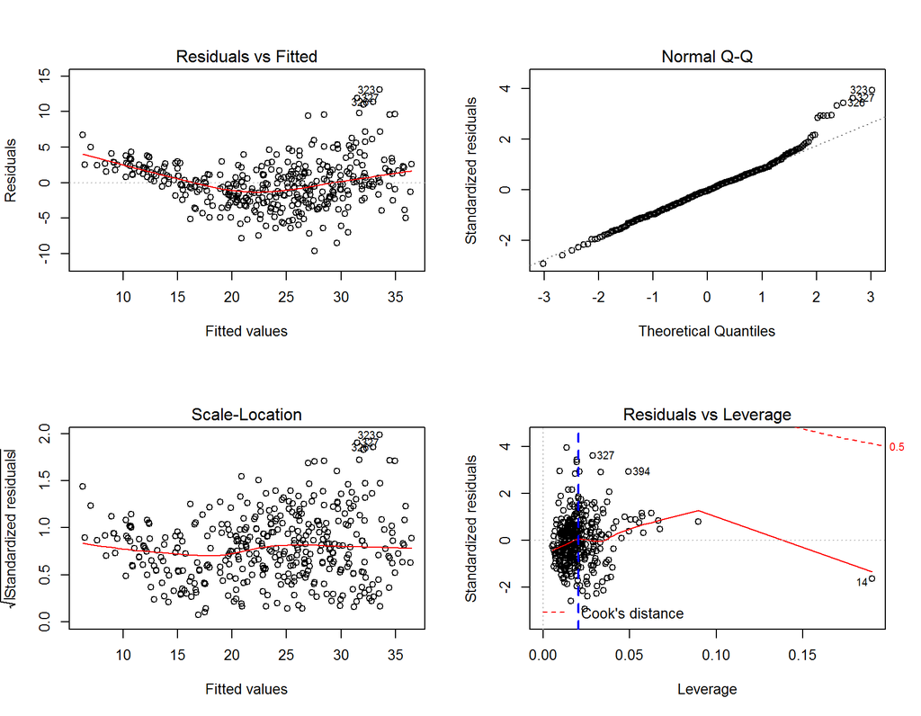

```r
par(mfrow=c(2,2))
plot(mod1)
abline(v=(7+1)/392, lty=2, lwd=2, col="blue")
```

```r
par(mfrow=c(1,1))
```

The residuals vs fitted plot suggest that 323, 326, 327 are the outliers with high residuals.

```r
which.max(hatvalues(mod1))
```

```
## 14
## 14
```

One observation 14 has relatively large leverage of around 0.20. In addition, the leverage cutoff is calculated as (p+1) / n = (7+1)/392= 0.02. Subject 327 and 394 are considered to have high leverage with a substantial residual. None of the points are close to the Cook’s distance contours.

### (e)

```r
mod2<-lm(mpg~cylinders*displacement*horsepower+ weight+ acceleration+ year: origin,data=auto)
summary(mod2)
```

```
##
## Call:
## lm(formula = mpg ~ cylinders * displacement * horsepower + weight +
##     acceleration + year:origin, data = auto)
##
## Residuals:
##      Min       1Q   Median       3Q      Max
## -11.4069  -2.2349  -0.3714   1.7061  16.8011
##
## Coefficients:
##                                     Estimate Std. Error t value Pr(>|t|)
## (Intercept)                       81.7277767 11.6608844   7.009 1.10e-11
## cylinders                         -4.4292404  2.1203619  -2.089  0.03738
## displacement                      -0.1625795  0.0857095  -1.897  0.05860
## horsepower                        -0.5259313  0.1184068  -4.442 1.17e-05
## weight                            -0.0014704  0.0008385  -1.754  0.08030
## acceleration                      -0.3673811  0.1208570  -3.040  0.00253
## cylinders:displacement             0.0149585  0.0114464   1.307  0.19206
## cylinders:horsepower               0.0493811  0.0187961   2.627  0.00896
## displacement:horsepower            0.0017698  0.0008657   2.044  0.04159
## year:origin                        0.0171026  0.0043115   3.967 8.70e-05
## cylinders:displacement:horsepower -0.0001908  0.0001112  -1.716  0.08705
##
## (Intercept)                       ***
## cylinders                         *
## displacement                      .
## horsepower                        ***
## weight                            .
## acceleration                      **
## cylinders:displacement
## cylinders:horsepower              **
## displacement:horsepower           *
## year:origin                       ***
## cylinders:displacement:horsepower .
## ---
## Signif. codes:  0 '***' 0.001 '**' 0.01 '*' 0.05 '.' 0.1 ' ' 1
##
## Residual standard error: 3.741 on 381 degrees of freedom
##   (5 observations deleted due to missingness)
## Multiple R-squared:  0.7762, Adjusted R-squared:  0.7703
## F-statistic: 132.1 on 10 and 381 DF,  p-value: < 2.2e-16
```

Cylinders:horsepower, displacement:horsepower and year:origin appear to be statistically significant.

### (f)

```r
auto$horsepower2 <- auto$horsepower^2
mod3<-lm(mpg~cylinders+displacement+horsepower2+ weight+ acceleration+ year+ origin,data=auto)
summary(mod3)
```

```
##
## Call:
## lm(formula = mpg ~ cylinders + displacement + horsepower2 + weight +
##     acceleration + year + origin, data = auto)
##
## Residuals:
##     Min      1Q  Median      3Q     Max
## -9.4398 -2.1891  0.0808  1.8067 13.0014
##
## Coefficients:
##                Estimate Std. Error t value Pr(>|t|)
## (Intercept)  -2.193e+01  4.303e+00  -5.096 5.44e-07 ***
## cylinders    -3.038e-01  3.280e-01  -0.926  0.35489
## displacement  1.094e-02  7.851e-03   1.394  0.16413
## horsepower2   8.282e-05  4.261e-05   1.944  0.05268 .
## weight       -7.110e-03  5.957e-04 -11.936  < 2e-16 ***
## acceleration  2.321e-01  8.691e-02   2.671  0.00788 **
## year          7.839e-01  5.053e-02  15.515  < 2e-16 ***
## origin        1.194e+00  2.807e-01   4.256 2.62e-05 ***
## ---
## Signif. codes:  0 '***' 0.001 '**' 0.01 '*' 0.05 '.' 0.1 ' ' 1
##
## Residual standard error: 3.318 on 384 degrees of freedom
##   (5 observations deleted due to missingness)
## Multiple R-squared:  0.8225, Adjusted R-squared:  0.8193
## F-statistic: 254.2 on 7 and 384 DF,  p-value: < 2.2e-16
```

If we square the `horsepower`, it becomes a marginally significant predictor and the model had slighly improved capability of explaining the variation.

```r
auto$mpg2 <- log(auto$mpg)
mod4<-lm(mpg2~cylinders+displacement+horsepower+ weight+ acceleration+ year+origin,data=auto)
summary(mod4)
```

```
##
## Call:
## lm(formula = mpg2 ~ cylinders + displacement + horsepower + weight +
##     acceleration + year + origin, data = auto)
##
## Residuals:
##      Min       1Q   Median       3Q      Max
## -0.40955 -0.06533  0.00079  0.06785  0.33925
##
## Coefficients:
##                Estimate Std. Error t value Pr(>|t|)
## (Intercept)   1.751e+00  1.662e-01  10.533  < 2e-16 ***
## cylinders    -2.795e-02  1.157e-02  -2.415  0.01619 *
## displacement  6.362e-04  2.690e-04   2.365  0.01852 *
## horsepower   -1.475e-03  4.935e-04  -2.989  0.00298 **
## weight       -2.551e-04  2.334e-05 -10.931  < 2e-16 ***
## acceleration -1.348e-03  3.538e-03  -0.381  0.70339
## year          2.958e-02  1.824e-03  16.211  < 2e-16 ***
## origin        4.071e-02  9.955e-03   4.089 5.28e-05 ***
## ---
## Signif. codes:  0 '***' 0.001 '**' 0.01 '*' 0.05 '.' 0.1 ' ' 1
##
## Residual standard error: 0.1191 on 384 degrees of freedom
##   (5 observations deleted due to missingness)
## Multiple R-squared:  0.8795, Adjusted R-squared:  0.8773
## F-statistic: 400.4 on 7 and 384 DF,  p-value: < 2.2e-16
```

If we make log transformation on the outcome variable `mpg`, `horsepower` becomes a significant predictor, and the the model had much improved capability of explaining the variation. These results indicate that there is no linear relationship between `mpg` and `horsepower`. The relationship is more likely to be quadratic or log-linear.

### 15. (a)

```r
library(MASS)

predictor<-names(Boston)[-1]

models <- lapply(predictor, function(x) {
    lm(substitute(crim ~ i, list(i = as.name(x))), data = Boston)
})

all <- lapply(models,summary)

sumr <- data.frame(estimate=1:13,std=1:13,t=1:13, p_value=1:13,row.names=predictor)

for(i in 1:13){
sumr[i,]<- all[[i]]$coefficients[2,]
}

sumr
```

```
##            estimate         std         t      p_value
## zn      -0.07393498 0.016094596 -4.593776 5.506472e-06
## indus    0.50977633 0.051024332  9.990848 1.450349e-21
## chas    -1.89277655 1.506115484 -1.256727 2.094345e-01
## nox     31.24853120 2.999190381 10.418989 3.751739e-23
## rm      -2.68405122 0.532041083 -5.044819 6.346703e-07
## age      0.10778623 0.012736436  8.462825 2.854869e-16
## dis     -1.55090168 0.168330031 -9.213458 8.519949e-19
## rad      0.61791093 0.034331820 17.998199 2.693844e-56
## tax      0.02974225 0.001847415 16.099388 2.357127e-47
## ptratio  1.15198279 0.169373609  6.801430 2.942922e-11
## black   -0.03627964 0.003873154 -9.366951 2.487274e-19
## lstat    0.54880478 0.047760971 11.490654 2.654277e-27
## medv    -0.36315992 0.038390175 -9.459710 1.173987e-19
```

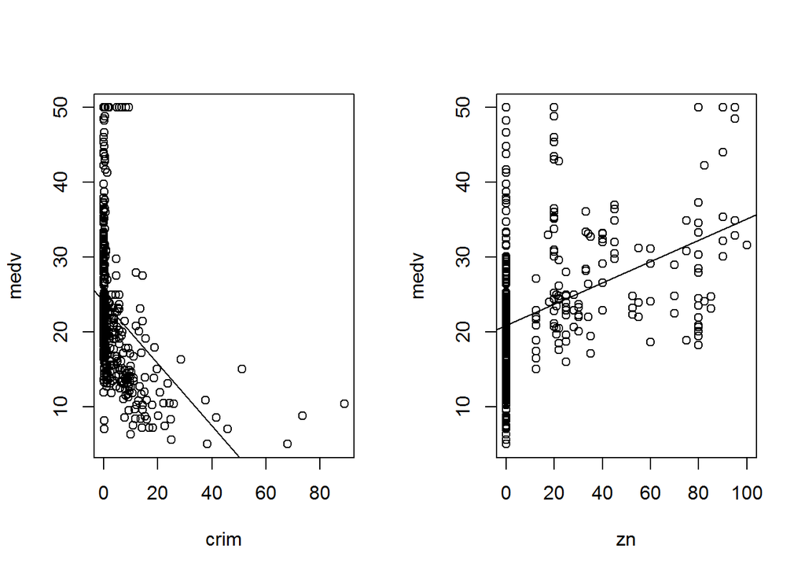

```r
par(mfrow=c(1,2))
with(Boston, plot(crim,medv))
abline(lm(medv~crim,data=Boston))

with(Boston, plot(zn,medv))
abline(lm(medv~zn,data=Boston))
```

By fitting 13 simple linear regression models, all predictors are statistically significant associated with the response expect for `chas`.

### (b)

```r
model.all <- lm(crim~. ,data=Boston)
summary(model.all)
```

```
##
## Call:
## lm(formula = crim ~ ., data = Boston)
##
## Residuals:
##    Min     1Q Median     3Q    Max
## -9.924 -2.120 -0.353  1.019 75.051
##
## Coefficients:
##               Estimate Std. Error t value Pr(>|t|)
## (Intercept)  17.033228   7.234903   2.354 0.018949 *
## zn            0.044855   0.018734   2.394 0.017025 *
## indus        -0.063855   0.083407  -0.766 0.444294
## chas         -0.749134   1.180147  -0.635 0.525867
## nox         -10.313535   5.275536  -1.955 0.051152 .
## rm            0.430131   0.612830   0.702 0.483089
## age           0.001452   0.017925   0.081 0.935488
## dis          -0.987176   0.281817  -3.503 0.000502 ***
## rad           0.588209   0.088049   6.680 6.46e-11 ***
## tax          -0.003780   0.005156  -0.733 0.463793
## ptratio      -0.271081   0.186450  -1.454 0.146611
## black        -0.007538   0.003673  -2.052 0.040702 *
## lstat         0.126211   0.075725   1.667 0.096208 .
## medv         -0.198887   0.060516  -3.287 0.001087 **
## ---
## Signif. codes:  0 '***' 0.001 '**' 0.01 '*' 0.05 '.' 0.1 ' ' 1
##
## Residual standard error: 6.439 on 492 degrees of freedom
## Multiple R-squared:  0.454,  Adjusted R-squared:  0.4396
## F-statistic: 31.47 on 13 and 492 DF,  p-value: < 2.2e-16
```

We can reject the null hypothesis for all `zn`, `dis`,`rad`,`black`,`medv`.

### (c)

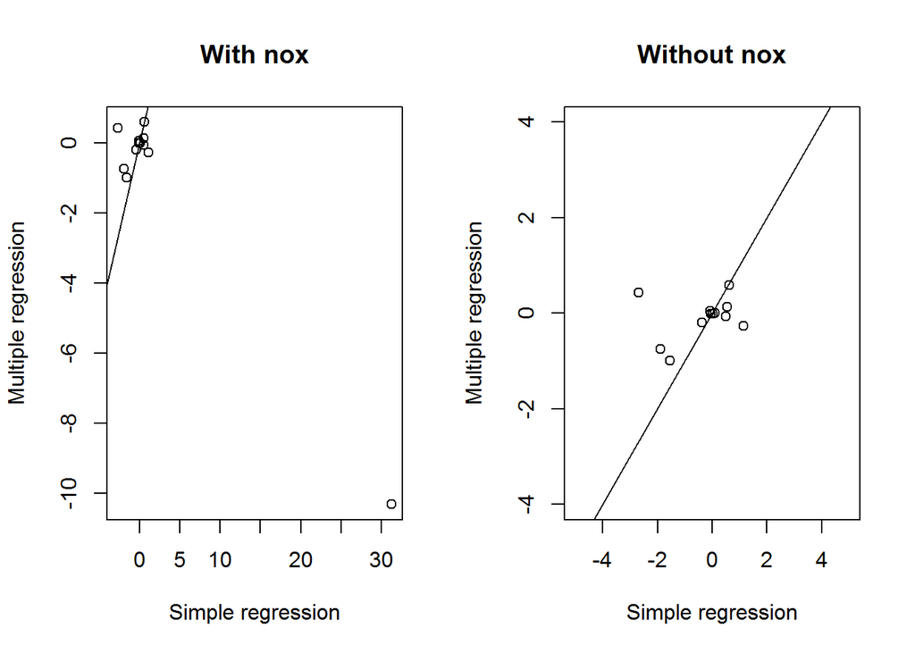

```r
par(mfrow=c(1,2))
plot(sumr[,1],as.numeric(model.all$coefficients[-1]),xlab = "Simple regression",ylab="Multiple regression",main="With nox")
abline(a=0,b=1)
plot(sumr[,1],as.numeric(model.all$coefficients[c(-1)]),xlab="Simple regression",ylab="Multiple regression",ylim = c(-4,4),xlim=c(-5,5),main="Without nox")
abline(a=0,b=1)
```

Most variables have closed estimates between simple regression and multiple regression while a few are not.

### (d)

```r
predictor2 <- predictor[-3]
nonlinear <- data.frame(estimate=1:39,std=1:39,t=1:39, p_value=1:39)


for (i in 1:12){
  j <- predictor2[i]
  model <- lm(paste("crim ~", j, "+I(",j, "^2)","+I(",j,"^3)" ), data=Boston)
  rows <- (i+2*(i-1)):(i+2+2*(i-1))
  output <- round(as.data.frame(summary(model)$coefficient[2:4,]),4)
  nonlinear[rows,] <- output
  row.names(nonlinear)[rows] <-  rownames(output,do.NULL=FALSE)
}



model.chas<-lm(crim~chas+I(chas^2)+I(chas^3),data=Boston)
nonlinear[37,]<-summary(model.chas)$coeff[2,]
nonlinear[38:39,]<-NA
rownames(nonlinear)[37:39] <- c("crim","I(chas^2)","I(chas^3)")

nonlinear
```

```
##                  estimate        std          t   p_value
## zn              -0.332200   0.109800  -3.025200 0.0026000
## I(zn^2)          0.006500   0.003900   1.679100 0.0938000
## I(zn^3)          0.000000   0.000000  -1.203000 0.2295000
## indus           -1.965200   0.482000  -4.077300 0.0001000
## I(indus^2)       0.251900   0.039300   6.407000 0.0000000
## I(indus^3)      -0.007000   0.001000  -7.292000 0.0000000
## nox          -1279.371300 170.397500  -7.508200 0.0000000
## I(nox^2)      2248.544100 279.899300   8.033400 0.0000000
## I(nox^3)     -1245.702900 149.281600  -8.344600 0.0000000
## rm             -39.150100  31.311500  -1.250300 0.2118000
## I(rm^2)          4.550900   5.009900   0.908400 0.3641000
## I(rm^3)         -0.174500   0.263700  -0.661500 0.5086000
## age              0.273700   0.186400   1.468300 0.1427000
## I(age^2)        -0.007200   0.003600  -1.987800 0.0474000
## I(age^3)         0.000100   0.000000   2.723700 0.0067000
## dis            -15.554400   1.736000  -8.960000 0.0000000
## I(dis^2)         2.452100   0.346400   7.078300 0.0000000
## I(dis^3)        -0.118600   0.020400  -5.813500 0.0000000
## rad              0.512700   1.043600   0.491300 0.6234000
## I(rad^2)        -0.075200   0.148500  -0.506100 0.6130000
## I(rad^3)         0.003200   0.004600   0.703100 0.4823000
## tax             -0.153300   0.095700  -1.602300 0.1097000
## I(tax^2)         0.000400   0.000200   1.487700 0.1375000
## I(tax^3)         0.000000   0.000000  -1.166800 0.2439000
## ptratio        -82.360500  27.643900  -2.979300 0.0030000
## I(ptratio^2)     4.635300   1.608300   2.882100 0.0041000
## I(ptratio^3)    -0.084800   0.030900  -2.743300 0.0063000
## black           -0.083600   0.056300  -1.483400 0.1386000
## I(black^2)       0.000200   0.000300   0.716200 0.4742000
## I(black^3)       0.000000   0.000000  -0.607800 0.5436000
## lstat           -0.449100   0.464900  -0.966000 0.3345000
## I(lstat^2)       0.055800   0.030100   1.852200 0.0646000
## I(lstat^3)      -0.000900   0.000600  -1.517000 0.1299000
## medv            -5.094800   0.433800 -11.743800 0.0000000
## I(medv^2)        0.155500   0.017200   9.045500 0.0000000
## I(medv^3)       -0.001500   0.000200  -7.312000 0.0000000
## crim            -1.892777   1.506115  -1.256727 0.2094345
## I(chas^2)              NA         NA         NA        NA
## I(chas^3)              NA         NA         NA        NA
```

Thus, many of them had non-linear association with the outcome. For example, `zn` only has linear relationship with outcome, but `indus` has a cubic relationship with the outcome. `chas` is a binary predictor which we cannot fit non-linear relationship.

## Titanic dataset

```r
train <- titanic::titanic_train %>%
          mutate(Id = as.factor(PassengerId),
                 Survived=as.factor(Survived),
                 Pclass = as.factor(Pclass),
                 Sex=as.factor(Sex),
                 Embarked=factor(Embarked,ordered=FALSE))%>%
          dplyr::select(Id,Survived,Pclass,Sex,Age,SibSp,Parch,Fare,Embarked)

test <- titanic::titanic_test%>%
          mutate(Id = as.factor(PassengerId),
                 Pclass = as.factor(Pclass),
                 Sex=as.factor(Sex),
                 Embarked=factor(Embarked,ordered=FALSE))%>%
          dplyr::select(Id,Pclass,Sex,Age,SibSp,Parch,Fare,Embarked)

summary(train)
```

```
##        Id      Survived Pclass      Sex           Age
##  1      :  1   0:549    1:216   female:314   Min.   : 0.42
##  2      :  1   1:342    2:184   male  :577   1st Qu.:20.12
##  3      :  1            3:491                Median :28.00
##  4      :  1                                 Mean   :29.70
##  5      :  1                                 3rd Qu.:38.00
##  6      :  1                                 Max.   :80.00
##  (Other):885                                 NA's   :177
##      SibSp           Parch             Fare        Embarked
##  Min.   :0.000   Min.   :0.0000   Min.   :  0.00    :  2
##  1st Qu.:0.000   1st Qu.:0.0000   1st Qu.:  7.91   C:168
##  Median :0.000   Median :0.0000   Median : 14.45   Q: 77
##  Mean   :0.523   Mean   :0.3816   Mean   : 32.20   S:644
##  3rd Qu.:1.000   3rd Qu.:0.0000   3rd Qu.: 31.00
##  Max.   :8.000   Max.   :6.0000   Max.   :512.33
##
```

First, start by checking collinearity problem.

```r
lrm1 <- lrm(Survived~ Pclass+Sex+Age+SibSp+Parch+Fare+Embarked, data=train)
rms::vif(lrm1)
```

```
##     Pclass=2     Pclass=3     Sex=male          Age        SibSp
##     2.227797     2.940987     1.199865     1.455545     1.279269
##        Parch         Fare   Embarked=C   Embarked=Q   Embarked=S
##     1.274946     1.615394 10439.002648  2349.365878 11896.819692
```

Embarked is an problematic variable, so it would not be included in models.

Next, considering the limited use of non-linear terms for predictors that look important in a spearman $\rho~^2~$ plot

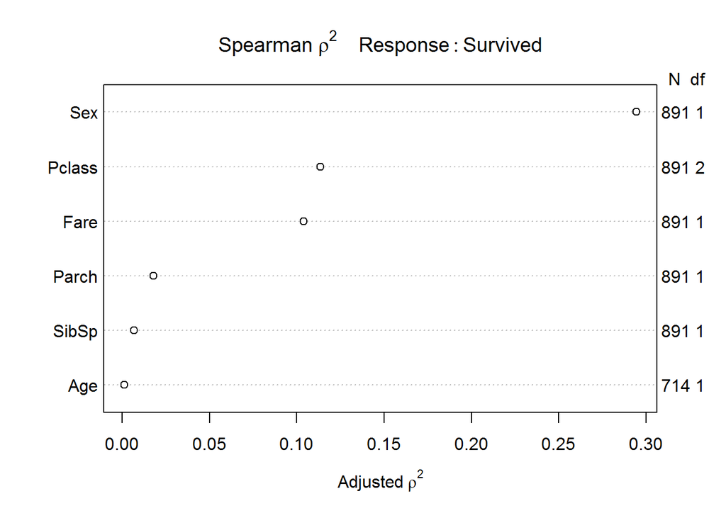

```r
plot(spearman2(Survived~ Pclass+Sex+Age+SibSp+Parch+Fare, data=train))
```

There might be an interaction term between `sex` and `Pclass`.

### Model A with interaction term

```r
d <- datadist(train)
options(datadist = "d")
lrmA <- lrm(Survived~ Pclass*Sex+Fare+Age+SibSp+Parch,x=T,y=T, data=train)
lrmA
```

```
## Frequencies of Missing Values Due to Each Variable
## Survived   Pclass      Sex     Fare      Age    SibSp    Parch
##        0        0        0        0      177        0        0
##
## Logistic Regression Model
##
##  lrm(formula = Survived ~ Pclass * Sex + Fare + Age + SibSp +
##      Parch, data = train, x = T, y = T)
##
##
##                        Model Likelihood     Discrimination    Rank Discrim.
##                           Ratio Test           Indexes           Indexes
##  Obs           714    LR chi2     362.18    R2       0.537    C       0.870
##   0            424    d.f.             9    g        2.254    Dxy     0.739
##   1            290    Pr(> chi2) <0.0001    gr       9.523    gamma   0.740
##  max |deriv| 2e-07                          gp       0.356    tau-a   0.357
##                                             Brier    0.132
##
##                      Coef    S.E.   Wald Z Pr(>|Z|)
##  Intercept            5.4399 0.7778  6.99  <0.0001
##  Pclass=2            -1.2034 0.7679 -1.57  0.1171
##  Pclass=3            -4.2220 0.7055 -5.98  <0.0001
##  Sex=male            -3.7285 0.6386 -5.84  <0.0001
##  Fare                 0.0010 0.0026  0.37  0.7097
##  Age                 -0.0514 0.0091 -5.66  <0.0001
##  SibSp               -0.3863 0.1270 -3.04  0.0023
##  Parch                0.0264 0.1305  0.20  0.8395
##  Pclass=2 * Sex=male -0.7111 0.8243 -0.86  0.3883
##  Pclass=3 * Sex=male  2.2081 0.6997  3.16  0.0016
##
```

```r
glmA<-glm(Survived~ Pclass*Sex+Fare+Age+SibSp+Parch,x=T,y=T, data=train,family = "binomial")
summary(glmA)
```

```
##
## Call:
## glm(formula = Survived ~ Pclass * Sex + Fare + Age + SibSp +
##     Parch, family = "binomial", data = train, x = T, y = T)
##
## Deviance Residuals:
##     Min       1Q   Median       3Q      Max
## -3.2106  -0.6565  -0.4314   0.3971   2.6122
##
## Coefficients:
##                   Estimate Std. Error z value Pr(>|z|)
## (Intercept)      5.4398602  0.7778128   6.994 2.68e-12 ***
## Pclass2         -1.2034469  0.7678652  -1.567  0.11705
## Pclass3         -4.2219827  0.7055186  -5.984 2.17e-09 ***
## Sexmale         -3.7284613  0.6385881  -5.839 5.26e-09 ***
## Fare             0.0009532  0.0025607   0.372  0.70972
## Age             -0.0513721  0.0090690  -5.665 1.47e-08 ***
## SibSp           -0.3862766  0.1269597  -3.043  0.00235 **
## Parch            0.0264328  0.1305490   0.202  0.83955
## Pclass2:Sexmale -0.7110763  0.8242542  -0.863  0.38831
## Pclass3:Sexmale  2.2080943  0.6997476   3.156  0.00160 **
## ---
## Signif. codes:  0 '***' 0.001 '**' 0.01 '*' 0.05 '.' 0.1 ' ' 1
##
## (Dispersion parameter for binomial family taken to be 1)
##
##     Null deviance: 964.52  on 713  degrees of freedom
## Residual deviance: 602.34  on 704  degrees of freedom
##   (177 observations deleted due to missingness)
## AIC: 622.34
##
## Number of Fisher Scoring iterations: 6
```

Looks like `Pclass`, `Sex`, `Age` and the interaction term have significant effect on the `Survived`.

#### Cross-validation for model A

```r
set.seed(471)
(Aval <- validate(lrmA))
```

```
##           index.orig training    test optimism index.corrected  n
## Dxy           0.7394   0.7357  0.7301   0.0057          0.7337 40
## R2            0.5369   0.5363  0.5250   0.0113          0.5256 40
## Intercept     0.0000   0.0000 -0.0400   0.0400         -0.0400 40
## Slope         1.0000   1.0000  0.9625   0.0375          0.9625 40
## Emax          0.0000   0.0000  0.0155   0.0155          0.0155 40
## D             0.5058   0.5063  0.4914   0.0149          0.4910 40
## U            -0.0028  -0.0028  0.0012  -0.0040          0.0012 40
## Q             0.5087   0.5091  0.4902   0.0188          0.4898 40
## B             0.1325   0.1329  0.1346  -0.0018          0.1342 40
## g             2.2537   2.3287  2.2245   0.1042          2.1495 40
## gp            0.3560   0.3555  0.3509   0.0046          0.3515 40
```

#### Getting an ROC curve after an lrm fit

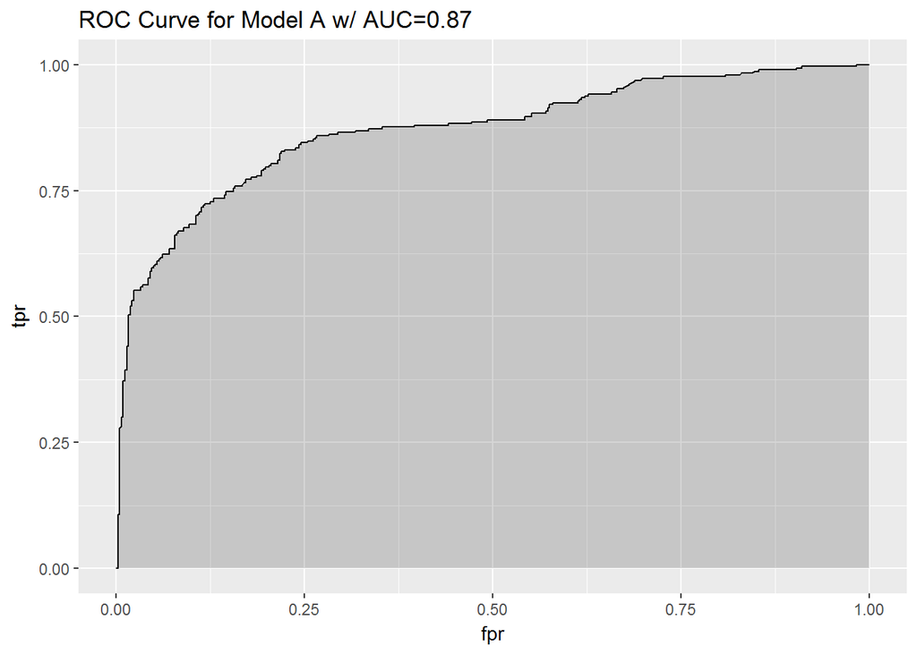

```r
prob <- predict(lrmA, type="fitted")
pred <- prediction(prob, train$Survived)
perf <- performance(pred, measure = "tpr", x.measure = "fpr")
auc <- performance(pred, measure="auc")

## the rest of this code is a little strange
auc <- round(auc@y.values[[1]],3)
aucA<-auc
roc.data <- data.frame(fpr=unlist(perf@x.values),
                       tpr=unlist(perf@y.values),
                       model="GLM")
ggplot(roc.data, aes(x=fpr, ymin=0, ymax=tpr)) +
    geom_ribbon(alpha=0.2) +
    geom_line(aes(y=tpr)) +
    ggtitle(paste0("ROC Curve for Model A w/ AUC=", auc))
```

A C statistic of 0.87 indicates good capability of discriminating the outcome.

### Model B without interaction

```r
lrmB <- lrm(Survived~ Pclass+Sex+Fare+Age+SibSp+Parch,x=T,y=T, data=train)
lrmB
```

```
## Frequencies of Missing Values Due to Each Variable
## Survived   Pclass      Sex     Fare      Age    SibSp    Parch
##        0        0        0        0      177        0        0
##
## Logistic Regression Model
##
##  lrm(formula = Survived ~ Pclass + Sex + Fare + Age + SibSp +
##      Parch, data = train, x = T, y = T)
##
##
##                        Model Likelihood     Discrimination    Rank Discrim.
##                           Ratio Test           Indexes           Indexes
##  Obs           714    LR chi2     328.74    R2       0.498    C       0.859
##   0            424    d.f.             7    g        2.053    Dxy     0.718
##   1            290    Pr(> chi2) <0.0001    gr       7.794    gamma   0.719
##  max |deriv| 1e-07                          gp       0.353    tau-a   0.347
##                                             Brier    0.141
##
##            Coef    S.E.   Wald Z Pr(>|Z|)
##  Intercept  4.1800 0.5034   8.30 <0.0001
##  Pclass=2  -1.2925 0.3218  -4.02 <0.0001
##  Pclass=3  -2.5011 0.3387  -7.38 <0.0001
##  Sex=male  -2.6375 0.2201 -11.98 <0.0001
##  Fare       0.0020 0.0026   0.80 0.4254
##  Age       -0.0442 0.0083  -5.34 <0.0001
##  SibSp     -0.3768 0.1275  -2.96 0.0031
##  Parch     -0.0613 0.1229  -0.50 0.6182
##
```

```r
glmB<-glm(Survived~ Pclass+Sex+Fare+Age+SibSp+Parch,x=T,y=T, data=train,family = "binomial")
```

#### Cross-validation for model B

```r
set.seed(4712)
(Bval <- validate(lrmB))
```

```
##           index.orig training    test optimism index.corrected  n
## Dxy           0.7184   0.7248  0.7135   0.0113          0.7071 40
## R2            0.4980   0.5093  0.4919   0.0174          0.4806 40
## Intercept     0.0000   0.0000 -0.0073   0.0073         -0.0073 40
## Slope         1.0000   1.0000  0.9685   0.0315          0.9685 40
## Emax          0.0000   0.0000  0.0083   0.0083          0.0083 40
## D             0.4590   0.4736  0.4519   0.0217          0.4373 40
## U            -0.0028  -0.0028  0.0004  -0.0032          0.0004 40
## Q             0.4618   0.4764  0.4515   0.0249          0.4369 40
## B             0.1408   0.1382  0.1424  -0.0043          0.1451 40
## g             2.0533   2.1174  2.0312   0.0863          1.9671 40
## gp            0.3532   0.3567  0.3505   0.0062          0.3470 40
```

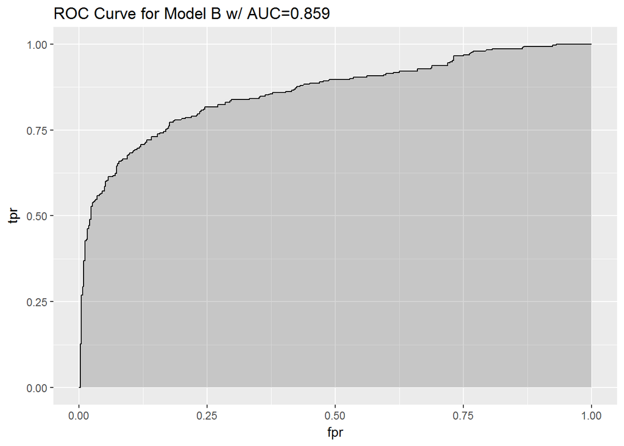

```r
prob <- predict(lrmB, type="fitted")
pred <- prediction(prob, train$Survived)
perf <- performance(pred, measure = "tpr", x.measure = "fpr")
auc <- performance(pred, measure="auc")

## the rest of this code is a little strange
auc <- round(auc@y.values[[1]],3)
aucB<-auc
roc.data <- data.frame(fpr=unlist(perf@x.values),
                       tpr=unlist(perf@y.values),
                       model="GLM")
ggplot(roc.data, aes(x=fpr, ymin=0, ymax=tpr)) +
    geom_ribbon(alpha=0.2) +
    geom_line(aes(y=tpr)) +
    ggtitle(paste0("ROC Curve for Model B w/ AUC=", auc))
```

A slightly reduced AUC value.

### Predictor selection

```r
MASS::stepAIC(glmA)
```

```
## Start:  AIC=622.34
## Survived ~ Pclass * Sex + Fare + Age + SibSp + Parch
##
##              Df Deviance    AIC
## - Parch       1   602.38 620.38
## - Fare        1   602.48 620.48
## <none>            602.34 622.34
## - SibSp       1   612.64 630.64
## - Pclass:Sex  2   635.78 651.78
## - Age         1   639.16 657.16
##
## Step:  AIC=620.38
## Survived ~ Pclass + Sex + Fare + Age + SibSp + Pclass:Sex
##
##              Df Deviance    AIC
## - Fare        1   602.57 618.57
## <none>            602.38 620.38
## - SibSp       1   613.42 629.42
## - Pclass:Sex  2   636.03 650.03
## - Age         1   639.17 655.17
##
## Step:  AIC=618.57
## Survived ~ Pclass + Sex + Age + SibSp + Pclass:Sex
##
##              Df Deviance    AIC
## <none>            602.57 618.57
## - SibSp       1   613.43 627.43
## - Pclass:Sex  2   636.56 648.56
## - Age         1   640.26 654.26
```

```
##
## Call:  glm(formula = Survived ~ Pclass + Sex + Age + SibSp + Pclass:Sex,
##     family = "binomial", data = train, x = T, y = T)
##
## Coefficients:
##     (Intercept)          Pclass2          Pclass3          Sexmale
##         5.55036         -1.27291         -4.29823         -3.75363
##             Age            SibSp  Pclass2:Sexmale  Pclass3:Sexmale
##        -0.05174         -0.37148         -0.69456          2.21899
##
## Degrees of Freedom: 713 Total (i.e. Null);  706 Residual
##   (177 observations deleted due to missingness)
## Null Deviance:       964.5
## Residual Deviance: 602.6     AIC: 618.6
```

### Reduced model C

```r
lrmC<-lrm(Survived ~ Pclass + Sex + Age + SibSp + Pclass:Sex,data=train)
lrmC
```

```
## Frequencies of Missing Values Due to Each Variable
## Survived   Pclass      Sex      Age    SibSp
##        0        0        0      177        0
##
## Logistic Regression Model
##
##  lrm(formula = Survived ~ Pclass + Sex + Age + SibSp + Pclass:Sex,
##      data = train)
##
##
##                        Model Likelihood     Discrimination    Rank Discrim.
##                           Ratio Test           Indexes           Indexes
##  Obs           714    LR chi2     361.95    R2       0.537    C       0.870
##   0            424    d.f.             7    g        2.252    Dxy     0.739
##   1            290    Pr(> chi2) <0.0001    gr       9.507    gamma   0.740
##  max |deriv| 9e-08                          gp       0.356    tau-a   0.357
##                                             Brier    0.133
##
##                      Coef    S.E.   Wald Z Pr(>|Z|)
##  Intercept            5.5504 0.7289  7.62  <0.0001
##  Pclass=2            -1.2729 0.7392 -1.72  0.0851
##  Pclass=3            -4.2982 0.6589 -6.52  <0.0001
##  Sex=male            -3.7536 0.6348 -5.91  <0.0001
##  Age                 -0.0517 0.0090 -5.73  <0.0001
##  SibSp               -0.3715 0.1199 -3.10  0.0020
##  Pclass=2 * Sex=male -0.6946 0.8210 -0.85  0.3976
##  Pclass=3 * Sex=male  2.2190 0.6912  3.21  0.0013
##
```

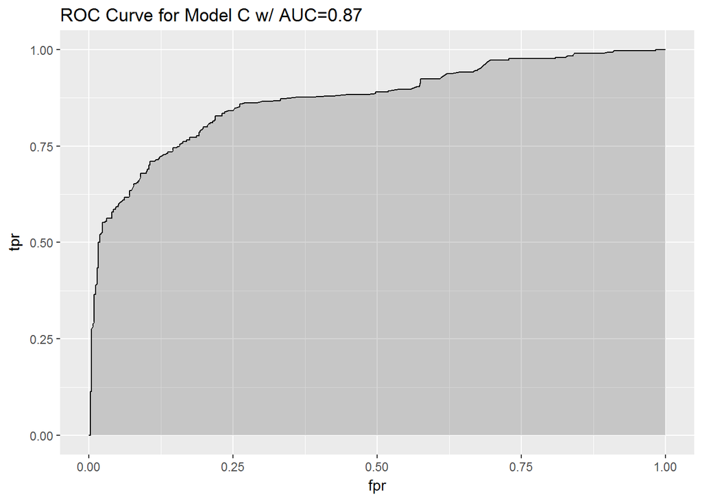

```r
prob <- predict(lrmC, type="fitted")
pred <- prediction(prob, train$Survived)
perf <- performance(pred, measure = "tpr", x.measure = "fpr")
auc <- performance(pred, measure="auc")

## the rest of this code is a little strange
auc <- round(auc@y.values[[1]],3)
aucC<-auc
roc.data <- data.frame(fpr=unlist(perf@x.values),
                       tpr=unlist(perf@y.values),
                       model="GLM")
ggplot(roc.data, aes(x=fpr, ymin=0, ymax=tpr)) +
    geom_ribbon(alpha=0.2) +
    geom_line(aes(y=tpr)) +
    ggtitle(paste0("ROC Curve for Model C w/ AUC=", auc))
```

```r
glmC <- glm(Survived ~ Pclass + Sex + Age + SibSp + Pclass:Sex,data=train,family = "binomial")
```

```r
data.frame(Model=c("Model A with interaction","Model B without insteraction","Model C Reduced model"),
           AIC = c(AIC(glmA),AIC(glmB),AIC(glmC)),
           C_statistic = c(aucA,aucB,aucC))
```

```
##                          Model      AIC C_statistic
## 1     Model A with interaction 622.3392       0.870
## 2 Model B without insteraction 651.7757       0.859
## 3        Model C Reduced model 618.5674       0.870
```

Reduced model and full model have equally higher C statistic, but reduced model has lower AIC. Thus, the reduced model is preferred.

### Predict the Survived outcome of the test data using Model C.

```r
pred <- predict.glm(glmC,newdata = test,type = "response")
data.frame(PassengerId=test$Id, Pred.Survive = round(pred))
```

```
##     PassengerId Pred.Survive
## 1           892            0
## 2           893            0
## 3           894            0
## 4           895            0
## 5           896            0
## 6           897            0
## 7           898            0
## 8           899            0
## 9           900            1
## 10          901            0
## 11          902           NA
## 12          903            0
## 13          904            1
## 14          905            0
```

[output cut: 404 more lines]

### Discussion

By looking at the top one of the discussion in Kernels, what I’ve learn from them is their various ways of data visualization including Mosaic Plot and a fancy Alluvial Diagram. They also used various approach of modeling and predicting, which is good way of doing research other than using a single method. The aspect that I may did better than them is using C statistic and AIC as a model selection criteria whereas they focus only on the prediction accuracy rate of test data.

## Chapter 4

### Logistic regression

```r
Boston$crim_bnr <- factor(ifelse(Boston$crim<median(Boston$crim), 0, 1))
names(Boston)
```

```
##  [1] "crim"     "zn"       "indus"    "chas"     "nox"      "rm"
##  [7] "age"      "dis"      "rad"      "tax"      "ptratio"  "black"
## [13] "lstat"    "medv"     "crim_bnr"
```

```r
glm1<-glm(crim_bnr~ .-crim, data=Boston,family = "binomial")
summary(glm1)
```

```
##
## Call:
## glm(formula = crim_bnr ~ . - crim, family = "binomial", data = Boston)
##
## Deviance Residuals:
##     Min       1Q   Median       3Q      Max
## -2.3946  -0.1585  -0.0004   0.0023   3.4239
##
## Coefficients:
##               Estimate Std. Error z value Pr(>|z|)
## (Intercept) -34.103704   6.530014  -5.223 1.76e-07 ***
## zn           -0.079918   0.033731  -2.369  0.01782 *
## indus        -0.059389   0.043722  -1.358  0.17436
## chas          0.785327   0.728930   1.077  0.28132
## nox          48.523782   7.396497   6.560 5.37e-11 ***
## rm           -0.425596   0.701104  -0.607  0.54383
## age           0.022172   0.012221   1.814  0.06963 .
## dis           0.691400   0.218308   3.167  0.00154 **
## rad           0.656465   0.152452   4.306 1.66e-05 ***
## tax          -0.006412   0.002689  -2.385  0.01709 *
## ptratio       0.368716   0.122136   3.019  0.00254 **
## black        -0.013524   0.006536  -2.069  0.03853 *
## lstat         0.043862   0.048981   0.895  0.37052
## medv          0.167130   0.066940   2.497  0.01254 *
## ---
## Signif. codes:  0 '***' 0.001 '**' 0.01 '*' 0.05 '.' 0.1 ' ' 1
##
## (Dispersion parameter for binomial family taken to be 1)
##
##     Null deviance: 701.46  on 505  degrees of freedom
## Residual deviance: 211.93  on 492  degrees of freedom
## AIC: 239.93
##
## Number of Fisher Scoring iterations: 9
```

```r
stats::step(glm1)
```

```
## Start:  AIC=239.93
## crim_bnr ~ (crim + zn + indus + chas + nox + rm + age + dis +
##     rad + tax + ptratio + black + lstat + medv) - crim
##
##           Df Deviance    AIC
## - rm       1   212.30 238.30
## - lstat    1   212.72 238.72
## - chas     1   213.09 239.09
## - indus    1   213.85 239.85
## <none>         211.93 239.93
## - age      1   215.37 241.37
## - tax      1   218.07 244.07
## - black    1   218.75 244.75
## - medv     1   218.82 244.82
## - zn       1   219.68 245.68
## - ptratio  1   221.91 247.91
## - dis      1   223.27 249.27
## - rad      1   252.03 278.02
## - nox      1   288.81 314.81
##
## Step:  AIC=238.3
## crim_bnr ~ zn + indus + chas + nox + age + dis + rad + tax +
##     ptratio + black + lstat + medv
##
##           Df Deviance    AIC
## - chas     1   213.48 237.48
## - lstat    1   213.76 237.76
## - indus    1   214.23 238.23
## <none>         212.30 238.30
## - age      1   215.53 239.53
## - tax      1   218.72 242.72
## - black    1   218.91 242.91
## - zn       1   220.51 244.51
## - ptratio  1   222.20 246.20
## - dis      1   223.27 247.27
## - medv     1   225.22 249.22
## - rad      1   252.22 276.22
## - nox      1   288.90 312.90
##
## Step:  AIC=237.48
```

[output cut: 34 more lines]

```
## Step:  AIC=236.22
## crim_bnr ~ zn + nox + age + dis + rad + tax + ptratio + black +
##     medv
##
##           Df Deviance    AIC
## <none>         216.22 236.22
## - age      1   221.78 239.78
## - black    1   222.52 240.52
## - ptratio  1   224.30 242.30
## - zn       1   225.78 243.78
## - dis      1   226.54 244.54
## - tax      1   227.52 245.52
## - medv     1   228.87 246.87
## - rad      1   267.04 285.04
## - nox      1   294.55 312.55
```

```
##
## Call:  glm(formula = crim_bnr ~ zn + nox + age + dis + rad + tax + ptratio +
##     black + medv, family = "binomial", data = Boston)
##
## Coefficients:
## (Intercept)           zn          nox          age          dis
##  -31.441272    -0.082567    43.195824     0.022851     0.634380
##         rad          tax      ptratio        black         medv
##    0.718773    -0.007676     0.303502    -0.012866     0.112882
##
## Degrees of Freedom: 505 Total (i.e. Null);  496 Residual
## Null Deviance:       701.5
## Residual Deviance: 216.2     AIC: 236.2
```

```r
glm2 <- glm(formula = crim_bnr ~ zn + nox + age + dis + rad + tax + ptratio +
    black + medv, family = "binomial", data = Boston)
summary(glm2)
```

```
##
## Call:
## glm(formula = crim_bnr ~ zn + nox + age + dis + rad + tax + ptratio +
##     black + medv, family = "binomial", data = Boston)
##
## Deviance Residuals:
##     Min       1Q   Median       3Q      Max
## -2.4197  -0.1840  -0.0004   0.0022   3.4087
##
## Coefficients:
##               Estimate Std. Error z value Pr(>|z|)
## (Intercept) -31.441272   6.048989  -5.198 2.02e-07 ***
## zn           -0.082567   0.031424  -2.628  0.00860 **
## nox          43.195824   6.452812   6.694 2.17e-11 ***
## age           0.022851   0.009894   2.310  0.02091 *
## dis           0.634380   0.207634   3.055  0.00225 **
## rad           0.718773   0.142066   5.059 4.21e-07 ***
## tax          -0.007676   0.002503  -3.066  0.00217 **
## ptratio       0.303502   0.109255   2.778  0.00547 **
## black        -0.012866   0.006334  -2.031  0.04224 *
## medv          0.112882   0.034362   3.285  0.00102 **
## ---
## Signif. codes:  0 '***' 0.001 '**' 0.01 '*' 0.05 '.' 0.1 ' ' 1
##
## (Dispersion parameter for binomial family taken to be 1)
##
##     Null deviance: 701.46  on 505  degrees of freedom
## Residual deviance: 216.22  on 496  degrees of freedom
## AIC: 236.22
##
## Number of Fisher Scoring iterations: 9
```

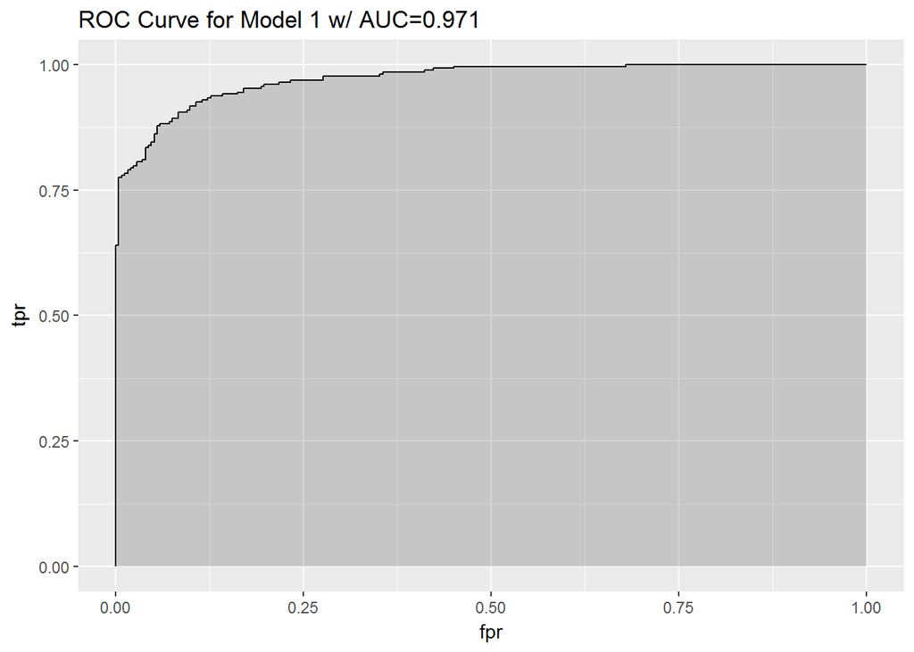

```r
logistic <- lrm(crim_bnr ~ zn + nox + age + dis + rad + tax + ptratio +
    black + medv, data = Boston)

prob <- predict(logistic, type="fitted")
pred <- prediction(prob, Boston$crim_bnr)
perf <- performance(pred, measure = "tpr", x.measure = "fpr")
auc <- performance(pred, measure="auc")


auc <- round(auc@y.values[[1]],3)
#aucB<-auc
roc.data <- data.frame(fpr=unlist(perf@x.values),
                       tpr=unlist(perf@y.values),
                       model="GLM")
ggplot(roc.data, aes(x=fpr, ymin=0, ymax=tpr)) +
    geom_ribbon(alpha=0.2) +
    geom_line(aes(y=tpr)) +
    ggtitle(paste0("ROC Curve for Model 1 w/ AUC=", auc))
```

This logistic regression model `crim_bnr ~ zn + nox + age + dis + rad + tax + ptratio + black + medv` has surprisingly good capabiliby of discriminating the crim classes with C statistic of 0.971.

```r
glm.probs <- predict(glm2, Boston, type="response")
glm.pred <- rep(0 ,506)
glm.pred[glm.probs > 0.5] <- 1
table(glm.pred, Boston$crim_bnr)
```

```
##
## glm.pred   0   1
##        0 232  25
##        1  21 228
```

```r
mean(glm.pred==Boston$crim_bnr)
```

```
## [1] 0.9090909
```

It appears that 91% were correctly predicted.

### LDA

```r
library(caret)
lda1<-lda(crim_bnr~.-crim,data=Boston)

confusionMatrix(predict(lda1)$class, Boston$crim_bnr, positive="0", mode="everything")
```

```
## Confusion Matrix and Statistics
##
##           Reference
## Prediction   0   1
##          0 240  60
##          1  13 193
##
##                Accuracy : 0.8557
##                  95% CI : (0.8221, 0.8852)
##     No Information Rate : 0.5
##     P-Value [Acc > NIR] : < 2.2e-16
##
##                   Kappa : 0.7115
##  Mcnemar's Test P-Value : 7.289e-08
##
##             Sensitivity : 0.9486
##             Specificity : 0.7628
##          Pos Pred Value : 0.8000
##          Neg Pred Value : 0.9369
##               Precision : 0.8000
##                  Recall : 0.9486
##                      F1 : 0.8680
##              Prevalence : 0.5000
##          Detection Rate : 0.4743
##    Detection Prevalence : 0.5929
##       Balanced Accuracy : 0.8557
##
##        'Positive' Class : 0
##
```

This full model produce the accuracy of predicting the crime rate as 0.8557.

Let’s try using the same variable set as in the logistic regressoin.

```r
lda2<-lda(crim_bnr~zn + nox + age + dis + rad + tax + ptratio + black + medv,data=Boston)

confusionMatrix(predict(lda2)$class, Boston$crim_bnr, positive="0", mode="everything")
```

```
## Confusion Matrix and Statistics
##
##           Reference
## Prediction   0   1
##          0 244  60
##          1   9 193
##
##                Accuracy : 0.8636
##                  95% CI : (0.8306, 0.8923)
##     No Information Rate : 0.5
##     P-Value [Acc > NIR] : < 2.2e-16
##
##                   Kappa : 0.7273
##  Mcnemar's Test P-Value : 1.752e-09
##
##             Sensitivity : 0.9644
##             Specificity : 0.7628
##          Pos Pred Value : 0.8026
##          Neg Pred Value : 0.9554
##               Precision : 0.8026
##                  Recall : 0.9644
##                      F1 : 0.8761
##              Prevalence : 0.5000
##          Detection Rate : 0.4822
##    Detection Prevalence : 0.6008
##       Balanced Accuracy : 0.8636
##
##        'Positive' Class : 0
##
```

The accuracy didn’t improve much.

### KNN

```r
library(class)
set.seed(471)

test.id<-sample(x = 1:506, size = 101, replace = FALSE, prob = NULL)

Boston$id<-1:506

test  <- Boston%>%filter(id %in% test.id)
train <- Boston[-which(Boston$id %in% test.id),]

knn1 <- knn(train = train[,c(-1,-15,-16)],
            test = test[,c(-1,-15,-16)],
            cl = train$crim_bnr,
            k=1)

table(knn1, test$crim_bnr)
```

```
##
## knn1  0  1
##    0 44  4
##    1  9 44
```

```r
mean(knn1==test$crim_bnr)
```

```
## [1] 0.8712871
```

```r
knn2 <- knn(train = train[,c(-1,-15,-16)],
            test = test[,c(-1,-15,-16)],
            cl = train$crim_bnr,
            k=3)

mean(knn2==test$crim_bnr)
```

```
## [1] 0.9009901
```

```r
knn3 <- knn(train = train[,c(-1,-15,-16)],
            test = test[,c(-1,-15,-16)],
            cl = train$crim_bnr,
            k=5)

mean(knn3==test$crim_bnr)
```

```
## [1] 0.9207921
```

```r
knn4 <- knn(train = train[,c(-1,-15,-16)],
            test = test[,c(-1,-15,-16)],
            cl = train$crim_bnr,
            k=7)

mean(knn4==test$crim_bnr)
```

```
## [1] 0.9108911
```